# Homework 9

# Submission Instructions

- Submit responses in a .ipynb file.
- For calculation questions:
  - Include R code used.
  - Ensure all code has been executed to display output.
  - Round *answers* to 3-5 decimal places if necessary.
  - Avoid displaying unnecessary R outputs.
  - Support conclusions with plots when checking assumptions.
  - Assume $\alpha = 0.05$ unless stated otherwise.
  - Two-sided hypothesis tests require two-sided confidence intervals.
  - One-sided hypothesis tests require one-sided confidence intervals.

# Question 1

Some archaeologists theorize that ancient Egyptians interbred with several different immigrant populations over thousands of years. To see if there is any indication of changes in body structure that might have resulted, they measured skulls of male Egyptians from 5 different epochs.

- Thomson and Randall-Maciver, *Ancient Races of the Thebaid*, Oxford: Oxford University Press, 1905.

The data can be found in **“SkullsComplete.csv”**. The column “mb” measures the maximum breadth of the skull in millimetres.

For the remaining questions, we will not be using the columns “bh”, “bl” or “nh”. Remove them from the dataframe and display the first 10 rows.

```r
library(tidyverse)

skulls <- read_csv("../Data/SkullsComplete.csv") |>
  select(epoch, mb)

skulls[1:10, ]
```

```
## # A tibble: 10 × 2
##    epoch      mb
##    <chr>   <dbl>
##  1 c4000BC   131
##  2 c4000BC   125
##  3 c4000BC   131
##  4 c4000BC   119
##  5 c4000BC   136
##  6 c4000BC   138
##  7 c4000BC   139
##  8 c4000BC   125
##  9 c4000BC   131
## 10 c4000BC   134
```

# Question 2

Create a barplot of the mean maximal breadth measured for each epoch in the **“SkullsComplete.csv”** data. Give the plot errorbars with 95% confidence intervals.

- Order the epochs so that, left to right, they go from earliest ($4000_\text{BC}$) to latest ($150_\text{AD}$). Note that years classified as “B.C.” count backwards. E.g., $3300_\text{BC}$ is more recent than $4000_\text{BC}$.
- Adjust the y-axis scale so that it goes from 120 at the bottom to 140 at the top.
- Give the plot a different colour scheme than ggplot’s default.

```r
#Factoring and ordering epoch
skulls$epoch <- factor(skulls$epoch,
  levels = c(
    "c4000BC",
    "c3300BC",
    "c1850BC",
    "c200BC",
    "cAD150"
  )
)
```

```r
# Getting statistics for plot
plot_data <- skulls |>
  group_by(epoch) |>
  summarise(
    n = length(mb),
    m = mean(mb),
    df = n - 1,
    alpha = 0.05,
    t_crit = abs(qt(alpha / 2, df = df)),
    se = sd(mb) / sqrt(n),
    moe = t_crit * se,
    ci_bot = m - moe,
    ci_top = m + moe
  )

print(plot_data)
```

```
## # A tibble: 5 × 10
##   epoch       n     m    df alpha t_crit     se   moe ci_bot ci_top
##   <fct>   <int> <dbl> <dbl> <dbl>  <dbl>  <dbl> <dbl>  <dbl>  <dbl>
## 1 c4000BC    30 131.4    29  0.05  2.045 0.9365 1.915  129.5  133.3
## 2 c3300BC    30 132.4    29  0.05  2.045 0.8782 1.796  130.6  134.2
## 3 c1850BC    30 134.5    29  0.05  2.045 0.6356 1.300  133.2  135.8
## 4 c200BC     30 135.5    29  0.05  2.045 0.7156 1.464  134.0  137.0
## 5 cAD150     30 136.2    29  0.05  2.045 0.9768 1.998  134.2  138.2
```

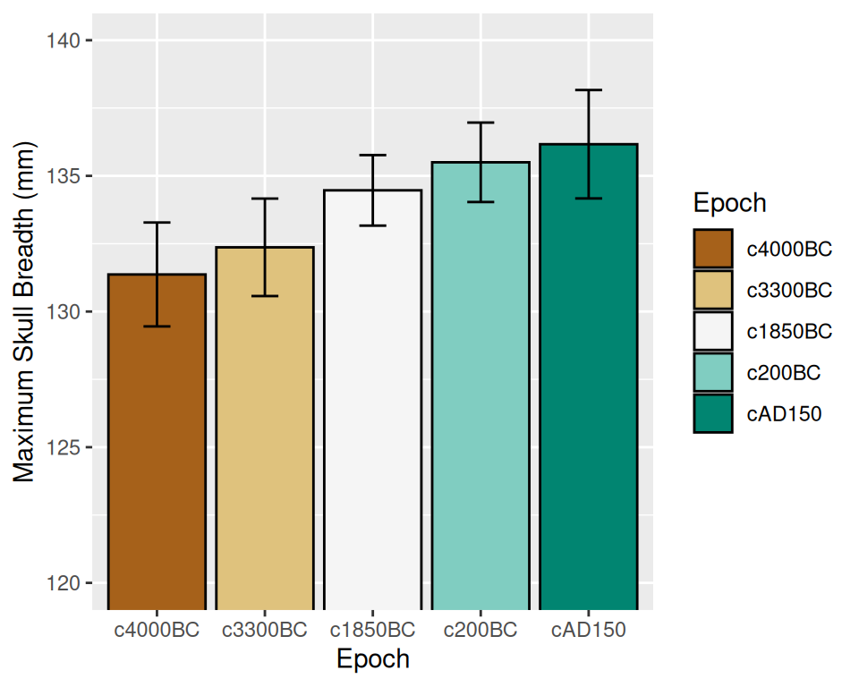

```r
library(RColorBrewer)

# Plot
ggplot(plot_data, aes(x = epoch, y = m)) +
  geom_bar(stat = "identity", aes(fill = epoch), colour = "black") +
  geom_errorbar(
    stat = "identity",
    aes(ymin = ci_bot, ymax = ci_top),
    width = .25
  ) +

  # Y-axis Scale Adjust
  coord_cartesian(ylim = c(120, 140)) +
  xlab("Epoch") +
  ylab("Maximum Skull Breadth (mm)") +
  labs(fill = "Epoch") +

  # Colours
  scale_fill_brewer(palette = "BrBG")
```

# Question 3

Using the **“SkullsComplete.csv”**, create a linear model predicting maximal breadth (mb) with coefficients that make the following comparisons:

- $b_0 = 4000_{\text{BC}}$
- $b_1 = 3300_{\text{BC}} - 4000_{\text{BC}}$
- $b_2 = 1850_{\text{BC}} - 4000_{\text{BC}}$
- $b_3 = 200_{\text{BC}} - 4000_{\text{BC}}$
- $b_4 = 150_{\text{AD}} - 4000_{\text{BC}}$

Report the model’s formula using the obtained coefficents.

- e.g. $\hat{y} = \text{(value)} + \text{(value)} x_1 + \text{(value)} x_2 \dots$

**There are two ways to achieve this: The first way is to use the `ifelse()` function to create your contrasts/dummy coding:**

```r
# Create n-1 (4) Dummy Variables
skulls$cont1 <- ifelse(skulls$epoch == "c3300BC", 1, 0)
skulls$cont2 <- ifelse(skulls$epoch == "c1850BC", 1, 0)
skulls$cont3 <- ifelse(skulls$epoch == "c200BC", 1, 0)
skulls$cont4 <- ifelse(skulls$epoch == "cAD150", 1, 0)
```

```r
#Model
skull_mod <- lm(mb ~ cont1 + cont2 + cont3 + cont4, data = skulls)
```

[output not shown]

**Formula:**

$\hat{y} = 131.367 + 1 \cdot x_1 + 3.1 \cdot x_2 + 4.133 \cdot x_3 + 4.8 \cdot x_4$

**The second way is to manually set the contrasts in R:**

```r
#Look at the ordering of the factor levels
levels(skulls$epoch)
```

```
## [1] "c4000BC" "c3300BC" "c1850BC" "c200BC"  "cAD150"
```

```r
# Create n-1 (4) Contrasts
cont1 <- c(0, 1, 0, 0, 0)
cont2 <- c(0, 0, 1, 0, 0)
cont3 <- c(0, 0, 0, 1, 0)
cont4 <- c(0, 0, 0, 0, 1)

contrasts(skulls$epoch) <- cbind(cont1, cont2, cont3, cont4)
contrasts(skulls$epoch)
```

```
##         cont1 cont2 cont3 cont4
## c4000BC     0     0     0     0
## c3300BC     1     0     0     0
## c1850BC     0     1     0     0
## c200BC      0     0     1     0
## cAD150      0     0     0     1
```

```r
#Model
skull_mod <- lm(mb ~ cont1 + cont2 + cont3 + cont4, data = skulls)
```

**Formula:**

$\hat{y} = 131.367 + 1 \cdot x_1 + 3.1 \cdot x_2 + 4.133 \cdot x_3 + 4.8 \cdot x_4$

# Question 4

Is the omnibus F-test from the previous question’s linear model statistically significant? Report it’s value, degrees of freedom and p-value.

- Ensure that the F-statistic and p-value are displayed to 6 decimal places.
- Hint: to get accurate results, you will need to extract values from the summary output.

```r
# F-Stat, df1, and df2
mod_sum <- summary(skull_mod)
round(mod_sum$fstatistic, 6)
```

```
##      value      numdf      dendf
##   5.954613   4.000000 145.000000
```

```r
# P-value
p_val <- pf(mod_sum$fstatistic[1],
  df1 = mod_sum$fstatistic[2],
  df2 = mod_sum$fstatistic[3],
  lower.tail = FALSE
)

round(p_val, 6)
```

```
##    value
## 0.000183
```

# Question 5

What do the results you displayed in the previous question tell you?

- There is **at least** one significant difference between the 5 different epochs.

# Question 6

Based on the planned contrasts/comparisons you used to evaluate the **“SkullsComplete.csv”** data, what epochs was there a significant difference between?

There is a significant difference between the following:

- $1850_{\text{BC}}$ & $4000_{\text{BC}}$
- $200_{\text{BC}}$ & $4000_{\text{BC}}$
- $150_{\text{AD}}$ & $4000_{\text{BC}}$

# Question 7

For the **“SkullsComplete.csv”** data, calculate an omnibus F-test manually without using `lm()` or `aov()`. Report the following . . . .

- Grand Mean
- Total Sum of Squares
- Model Sum of Squares
- Residual Sum of Squares
- Model Mean Squares
- Residual Mean Squares
- Multiple $R^2$
- F statistic
- p-value

```r
grand_m <- mean(skulls$mb)
```

```r
SST <- sum((skulls$mb - grand_m)^2)
```

```r
SSM <- sum(plot_data$n * (plot_data$m - grand_m)^2)
```

```r
SSR <- SST - SSM
```

```r
R_sq <- SSM/SST
```

```r
# Degrees of Freedom
df_t <- nrow(skulls) - 1
df_m <- 5 - 1
df_r <- df_t - df_m
```

```r
# Mean Squares
MSm <- SSM / df_m
MSr <- SSR / df_r
```

```r
F_stat <- MSm / MSr
```

```r
p <- pf(F_stat, df1 = df_m, df2 = df_r, lower.tail = FALSE)
```

[output not shown]

# Question 8

Does the model you created for the **“SkullsComplete.csv”** data violate the normality assumption?

**Note: There are two different ways to check this, either is correct.**

**Option 1:** Check the model Residuals

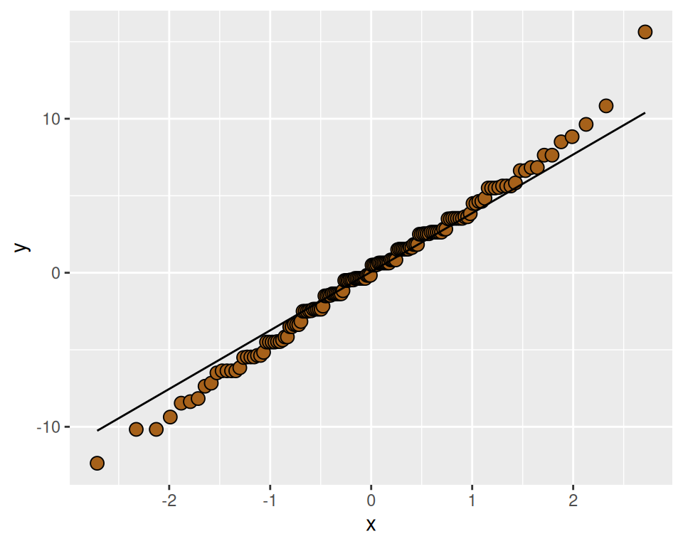

```r
library(RColorBrewer)
palette <- brewer.pal(5,'BrBG')
# this is for colouring my plot pretty colours

ggplot(mapping = aes(sample = mod_sum$residuals)) +
  stat_qq(
    shape = 21,
    colour = "black",
    fill = palette[1],
    size = 3
  ) +
  stat_qq_line()
```

**Option 2:** Check the normality of the epoch levels

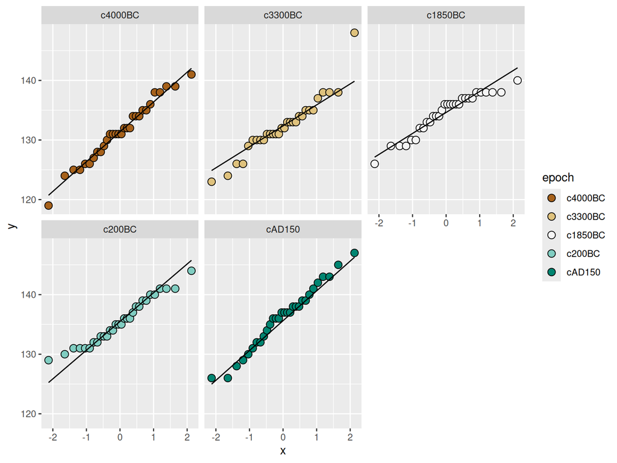

```r
ggplot(skulls, aes(sample = mb)) +
  stat_qq(
    shape = 21,
    colour = "black",
    aes(fill = epoch),
    size = 3
  ) +
  stat_qq_line() +
  facet_wrap(~ epoch) +
  scale_fill_brewer(palette = "BrBG")
```

The data seem to be acceptably normally distributed.

# Question 9

The data **“salary.csv”** shows the salary of different high-level job positions.

Use polynomial contrasts to determine which type of trends are most appropriate to describe this data. i.e., specify which trend types are significant.

```r
# Load Data
salary <- read_csv("../Data/salary.csv")

# Factor Data
salary$Level <- factor(salary$Level)

# Create Contrasts
contrasts(salary$Level) <- contr.poly(levels(salary$Level))
# contrasts(salary$Level)

# Model
model <- lm(Salary ~ Level, data = salary)
round(summary(model)$coefficients, 4)
```

```
##                Estimate Std. Error t value Pr(>|t|)
## (Intercept) 183386.9462   5292.694 34.6491   0.0000
## Level.L     432933.2475  16736.967 25.8669   0.0000
## Level.Q     164613.3149  16736.967  9.8353   0.0000
## Level.C      20357.7838  16736.967  1.2163   0.2262
## Level^4      -3561.9625  16736.967 -0.2128   0.8318
## Level^5        906.9127  16736.967  0.0542   0.9569
## Level^6      15563.8677  16736.967  0.9299   0.3543
## Level^7      15804.0407  16736.967  0.9443   0.3469
## Level^8        837.8319  16736.967  0.0501   0.9602
## Level^9       4684.8657  16736.967  0.2799   0.7800
```

Linear and Quadratic are both significant.

# Question 10

Write out the simplest polynomial equation/model (with the obtained $b$ values) that **BEST** describes the trend seen in the **salary.csv** data.

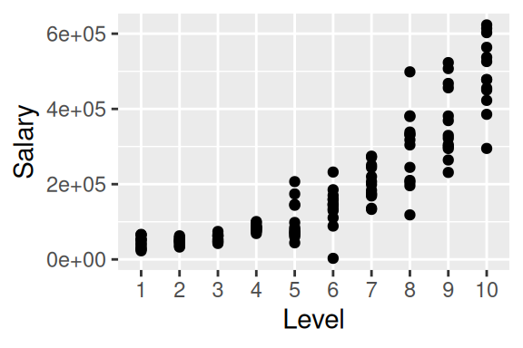

```r
# Looking at a plot of the data . . .
ggplot(salary, aes(x = Level, y = Salary)) +
  geom_point()
```

```r
# Plot is too curved to be linear and kinda looks like half of a parabola.

# Undo factoring:
salary$Level <- as.numeric(as.character(salary$Level))

# Building new model
salary$Level2 <- salary$Level^2

quad_mod <- lm(Salary ~ Level + Level2, data = salary)
```

**Formula:**

$\hat{y} = 78838.1 + -31138.2 \cdot x_1 + 7163.9 \cdot x_2$

Note: showing the plot is not necessary for full marks, I just did it to show my reasoning process. Other ways to do this would be to fit both the linear and quadratic model and compare the plotted models, compare the $R^2$ values, or run an F-test between them (i.e., `anova()`).

# Question 11

Plot the equation from the previous question as a smooth line on top of the observed values.

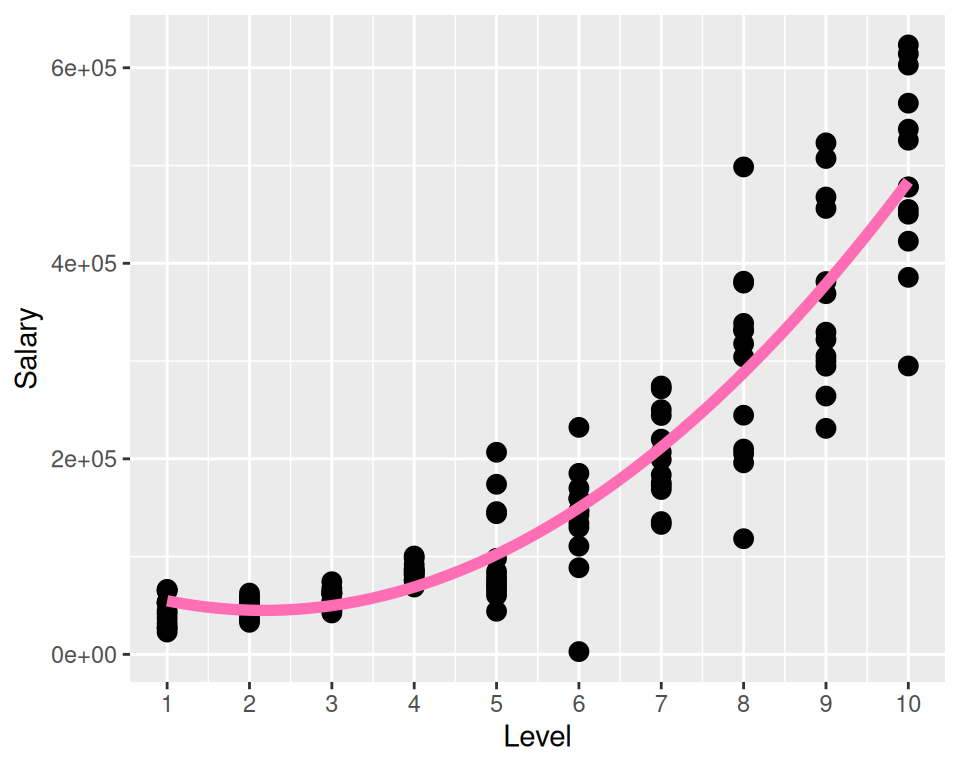

```r
# Values to predict.
x <- seq(1, 10, by = .01)

# Predicted Values
y <- quad_mod$coefficients[1] +
  quad_mod$coefficients[2] * x +
  quad_mod$coefficients[3] * x^2

# Plot
mod_pred <- data.frame(x, y)

ggplot(salary, aes(x = Level, y = Salary)) +
  geom_point(size = 3) +
  geom_line(
    data = mod_pred,
    aes(x = x, y = y),
    colour = "hotpink1",
    linewidth = 2
  ) +
  scale_x_continuous(breaks = 1:10)
```